# Which Levels of Physiochemicals Effect Wine Type and Quality?

Rhedt Roelandt, Calvin Skalla, & Cory Skeers

5/7/2020

> **Introduction**

Have you ever wondered what levels of physiochemicals will result in a high quality tasting wine? Do you know, just based off a few certain features, if a wine is red or white? Well, through this analysis, we will be demonstrating which chemicals have relationships with the quality of a wine and the key differences between red and white wines. Now, if you click below, we will explain the variables within the red and white wine datasets that were provided by *UCI Machine Learning Repository*.

**Click to expand the variables and their descriptions**

| Variable | Description |
| --- | --- |
| `Sample Number` | Number given to each invdividual wine sample |
| `Type` | Type of wine: 1 is white & 0 is red |
| `Like` | Rating of wine: 1 is good & 0 is bad |
| `Quality` | Rating score on the quality of wine |
| `Fixed Acidity` | Amount of acid from the grapes |
| `Volatile Acidity` | Amount of distillable acid in the wine |
| `Citric Acid` | Amount of citric acid present to add flavor |
| `Residual Sugar` | Leftover sugar from grapes after alcohol fermentation |
| `Chlorides` | Amount of salt in the wine |
| `Free Sulfur Dioxide` | Amount of $SO_2$ not bound to other molecules |
| `Total Sulfur Dioxide` | Portion of free $SO_2$ plus the portion bounded to the other chemicals |
| `Density` | Mass of dissolved solids |
| `pH` | Measure of relative acidity vs. relative alkalinity of any liquid |
| `Sulfites` | Amount of preservative ($SO_2$) for antioxidant and antibacterial properties |
| `Alcohol` | Percent of alcohol content in the wine sample |

The eleven numerical variables to differentiate the wines were given in grams per liter or per milliter, besides alcohol and density, which came in percentages. These variables, listed above, offer different levels of sweetness, bitterness, and acidity for the wines. Along with the variables we scraped, we created two additional columns for our analysis. When combining the red and white wine datasets, We mutated a `type` column to distinguish a 1 as a white wine and a 0 for a red wine. Then to interpret `quality` a little simpler, we created a binary `like` variable resulting in a 1 with `quality` greater than 5 and a 0 with `quality` less than or equal to 5.

**Click to get a glimpse of the Wine Dataset**

Wine Dataset

| Sample Number | Type | Like | Quality | Fixed Acidity | Volatile Acidity | Citric Acid | Residual Sugar | Chlorides | Free Sulfur Dioxide | Total Sulfur Dioxide | Density | pH | Sulfites | Alcohol |
| --- | --- | --- | --- | --- | --- | --- | --- | --- | --- | --- | --- | --- | --- | --- |
| 5668 | 0.00 | 0.00 | 5.00 | 7.90 | 0.72 | 0.01 | 1.90 | 0.076 | 7.00 | 32.00 | 0.99668 | 3.39 | 0.54 | 9.60 |
| 2223 | 1.00 | 1.00 | 7.00 | 8.00 | 0.45 | 0.28 | 10.80 | 0.051 | 25.00 | 157.00 | 0.99570 | 3.06 | 0.47 | 11.40 |
| 5989 | 0.00 | 1.00 | 8.00 | 10.00 | 0.26 | 0.54 | 1.90 | 0.083 | 42.00 | 74.00 | 0.99451 | 2.98 | 0.63 | 11.80 |
| 6428 | 0.00 | 1.00 | 6.00 | 7.10 | 0.69 | 0.08 | 2.10 | 0.063 | 42.00 | 52.00 | 0.99608 | 3.42 | 0.60 | 10.20 |
| 6354 | 0.00 | 1.00 | 6.00 | 6.50 | 0.90 | 0.00 | 1.60 | 0.052 | 9.00 | 17.00 | 0.99467 | 3.50 | 0.63 | 10.90 |
| 5582 | 0.00 | 0.00 | 5.00 | 8.10 | 0.78 | 0.23 | 2.60 | 0.059 | 5.00 | 15.00 | 0.99700 | 3.37 | 0.56 | 11.30 |
| 2500 | 1.00 | 1.00 | 6.00 | 6.90 | 0.26 | 0.31 | 7.00 | 0.039 | 37.00 | 175.00 | 0.99376 | 3.32 | 0.49 | 11.40 |
| 2057 | 1.00 | 0.00 | 5.00 | 6.80 | 0.21 | 0.27 | 18.15 | 0.042 | 41.00 | 146.00 | 1.00010 | 3.30 | 0.36 | 8.70 |
| 2400 | 1.00 | 1.00 | 6.00 | 6.10 | 0.16 | 0.24 | 1.40 | 0.046 | 17.00 | 77.00 | 0.99319 | 3.66 | 0.57 | 10.30 |
| 5732 | 0.00 | 0.00 | 4.00 | 11.60 | 0.47 | 0.44 | 1.60 | 0.147 | 36.00 | 51.00 | 0.99836 | 3.38 | 0.86 | 9.90 |
| Means | 0.75 | 0.63 | 5.82 | 7.22 | 0.34 | 0.32 | 5.44 | 0.060 | 30.53 | 115.74 | 0.99000 | 3.22 | 0.53 | 10.49 |

* 10 random wines chosen from the 6497 samples with the means of the dataset calculated at the bottom

The numerical variables were given in grams per liter or per milliter, besides alcohol and density, which came in percentages. Since the variables were given on different scales, for our analysis, we needed to use a method called min-max to create a dataset with normalized data. By using min-max normalization, we change our maximum observation in that column to a new value of 1 and the minimum of that column to a new value of 0. Then, for the rest of the values, calculate that difference between the value and the minimum divided by the difference between the maximum and minimum to receive all of your values on a [0,1] scale.

**Click here to expand the correlation of each variable with Quality**

Correlation of Each Variable with Quality

| Variables | Correlation | Significance |
| --- | --- | --- |
| Alcohol | 0.4443185 | (+++) |
| Citric Acid | 0.0855317 | (+) |
| Free Sulfur Dioxide | 0.0554631 | NSF |
| Sulfites | 0.0384854 | NSF |
| pH | 0.0195057 | NSF |
| Residual Sugar | -0.0369805 | NSF |
| Total Sulfur Dioxide | -0.0413855 | NSF |
| Fixed Acidity | -0.0767432 | NSF |
| Chlorides | -0.2006655 | (- -) |
| Volatile Acidity | -0.2656995 | (- -) |
| Density | -0.3058579 | (- - -) |

<sup>1</sup> (+) refers to having a positive correlation with quality  
<sup>2</sup> NSF refers to not having a sufficient correlation with quality  
<sup>3</sup> (-) refers to having negative correlation with quality

> **Visualizations to Gather Knowledge about the Variables**

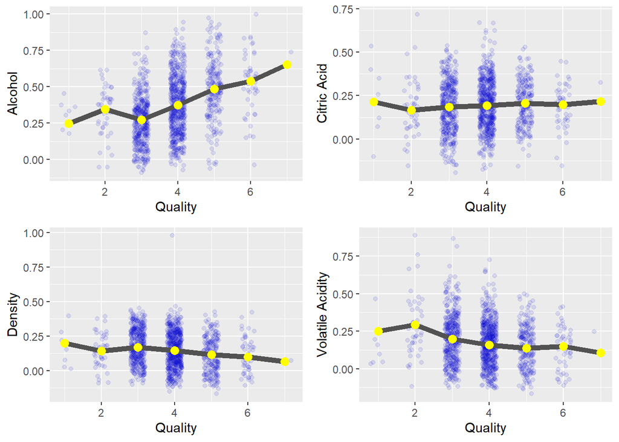

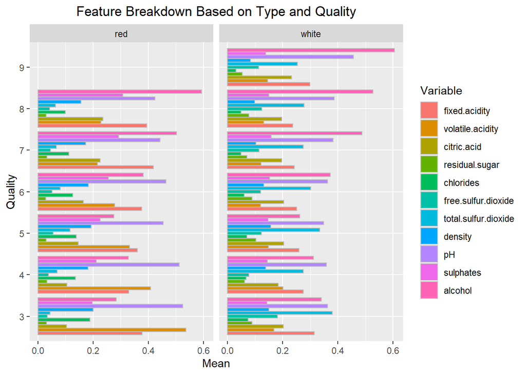

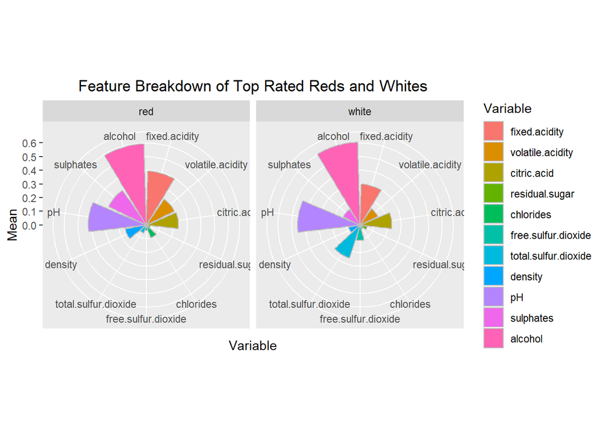

> **Predicting Wine Quality**

For predicting the quality of wines, we will use a Random Forest. When looking at the density plots of quality over red and white wines, we can perceive that there are more wines with a mediocre quality rating compared to wines with extreme quality ratings. Hence, we can assume that these wines are distributed normally. These distributions are also relatively equivalent between both types of wine.

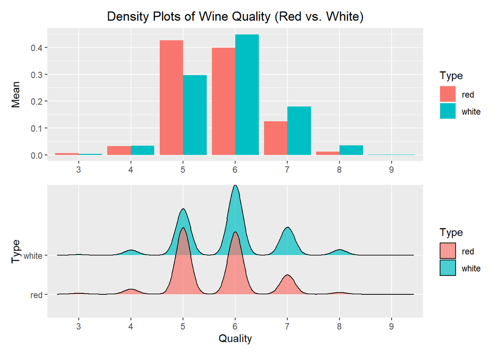

Using a Random Forest method on a 90-10 split of train-test data, we attempt to classify a wine’s quality rating based on its physiochemical properties.

In addition to the low computational complexity in applying a fitted Random Forest model for future inference, the weighted importance rating for each variable is beneficial for interpretation.

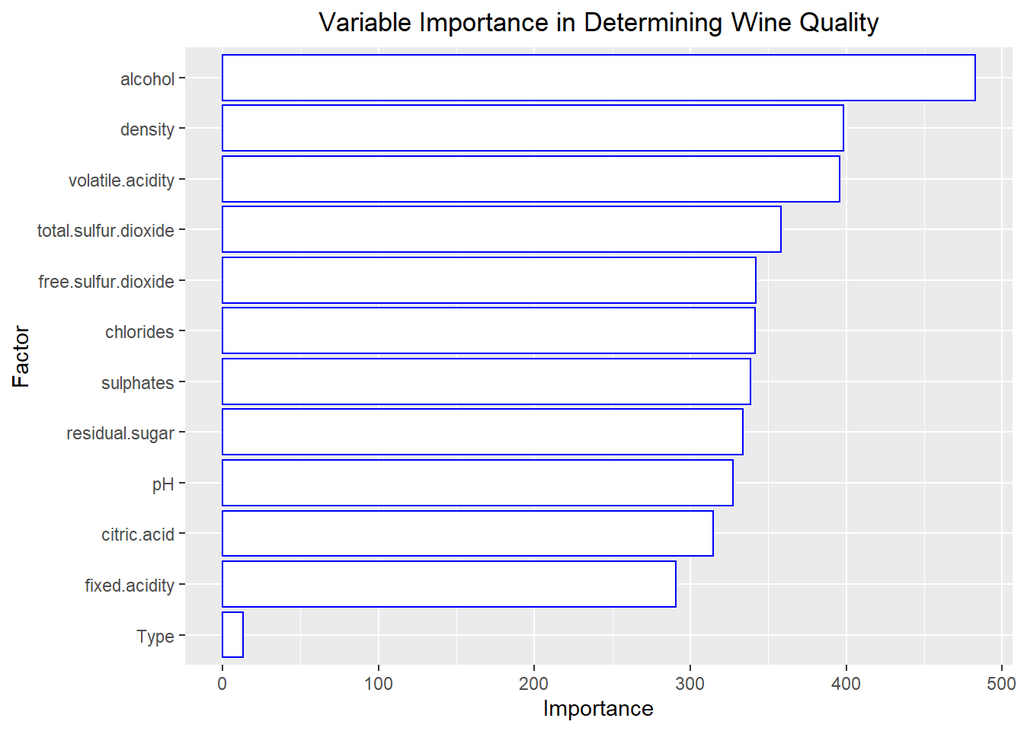

As you can see, the variables determined through the Random Forest model selection to have great importance in predicting a wine’s quality match nicely with the variables with significant correlation. The relatively low importance rating for Type is to be expected as well, given the rough equivalence in the distributions of quality ratings for both white and red wines.

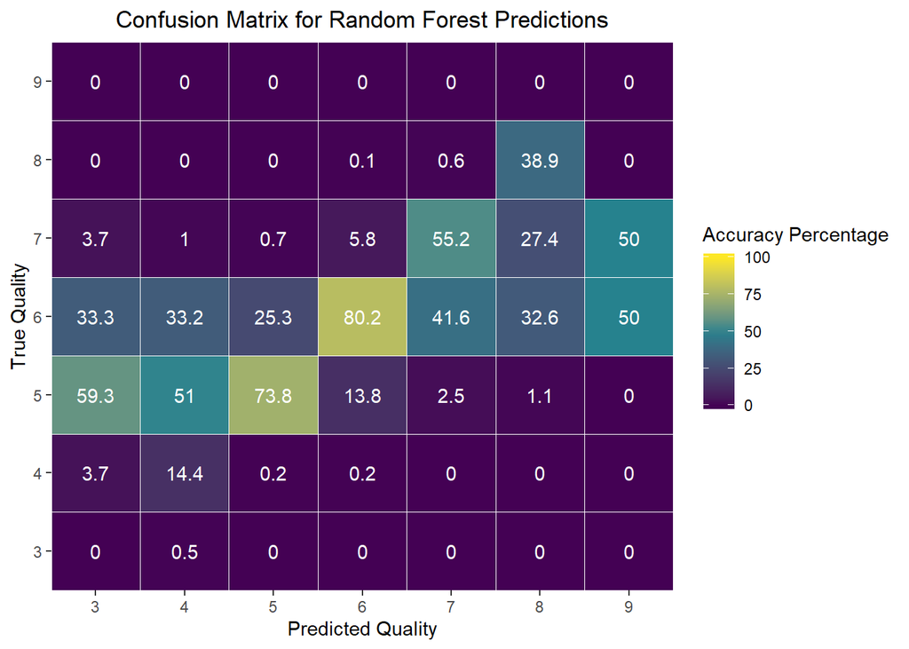

And using the fitted model with our holdout test data…

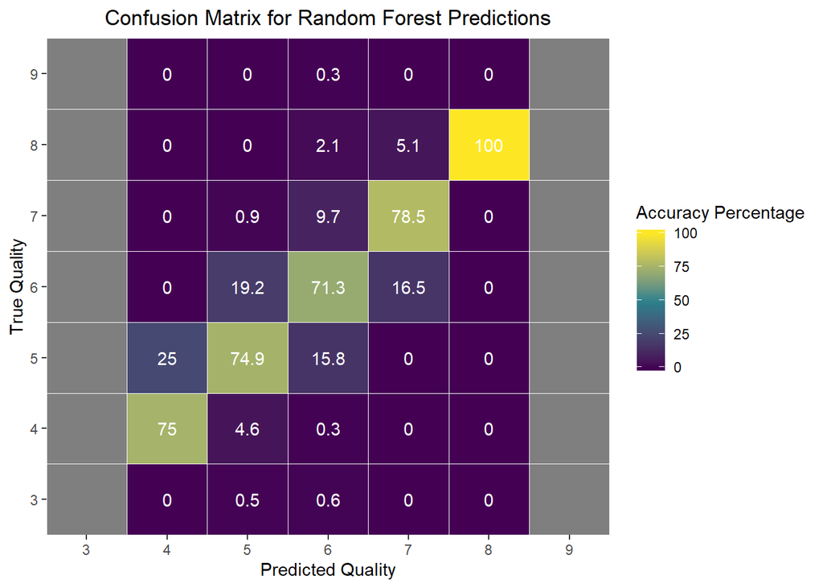

It’s relatively high performance in testing also provides support to the estimated importance of several of the variables, such as alcohol percentage, density, and volatilic acidity, in determining quality.

> **Predicting Wine Type**

When pivoting to project which variables are significant in predicting the type of quality, we chose to use a few Logistic Regression models. Interestingly enough, from our results in predicting quality, the alcohol percentage was extremely important in correctly classifying a quality. However, looking at this violin plot distribution of alcohol percentage for white and red wines, we see rather similar distributions. So, first, we created a model based off the variables derived from a best subset selection. Then, we decided to produce a few singular variable logistic regression models for interpretability and visualizations.

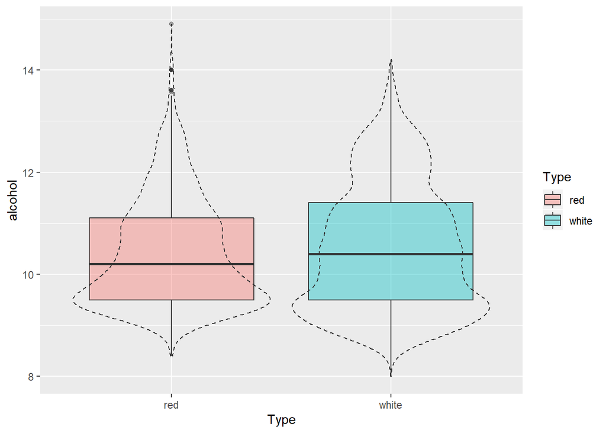

For our model derived from a best subset selection, we ended up with the following variables to conduct the best analysis. Looking at the coefficent estimates and p-values, we can see that all eight of these variables are significant in predicting the type of wine for this model. Noticably, the p-value of `density` happened to be extremely low.

|  | Estimate | Std. Error | z value | Pr(>\|z\|) |
| --- | --- | --- | --- | --- |
| **(Intercept)** | 15.13 | 1.241 | 12.19 | 3.649e-34 |
| **volatile.acidity** | -8.792 | 1.567 | -5.609 | 2.032e-08 |
| **citric.acid** | 5.161 | 1.949 | 2.648 | 0.008099 |
| **residual.sugar** | 60.87 | 5.743 | 10.6 | 2.985e-26 |
| **chlorides** | -15.01 | 2.367 | -6.34 | 2.294e-10 |
| **free.sulfur.dioxide** | -16.08 | 4.222 | -3.807 | 0.0001405 |
| **total.sulfur.dioxide** | 20.95 | 2.133 | 9.822 | 9.025e-23 |
| **density** | -87.71 | 5.836 | -15.03 | 4.608e-51 |
| **alcohol** | -12.89 | 1.448 | -8.906 | 5.305e-19 |

(Dispersion parameter for binomial family taken to be 1 )

| Null deviance: | 5750.2 on 5196 degrees of freedom |
| --- | --- |
| Residual deviance: | 400.5 on 5188 degrees of freedom |

#### Now we will move onto the Singular Models

After running `Type` against each variable indpendently, we noticed three variables that are greatly significant in predicting wine type themselves. So, we created these three singular models with `Type` imposed onto `total.sulfur.dioxide`, `chlorides`, and `volatile.acidity`.

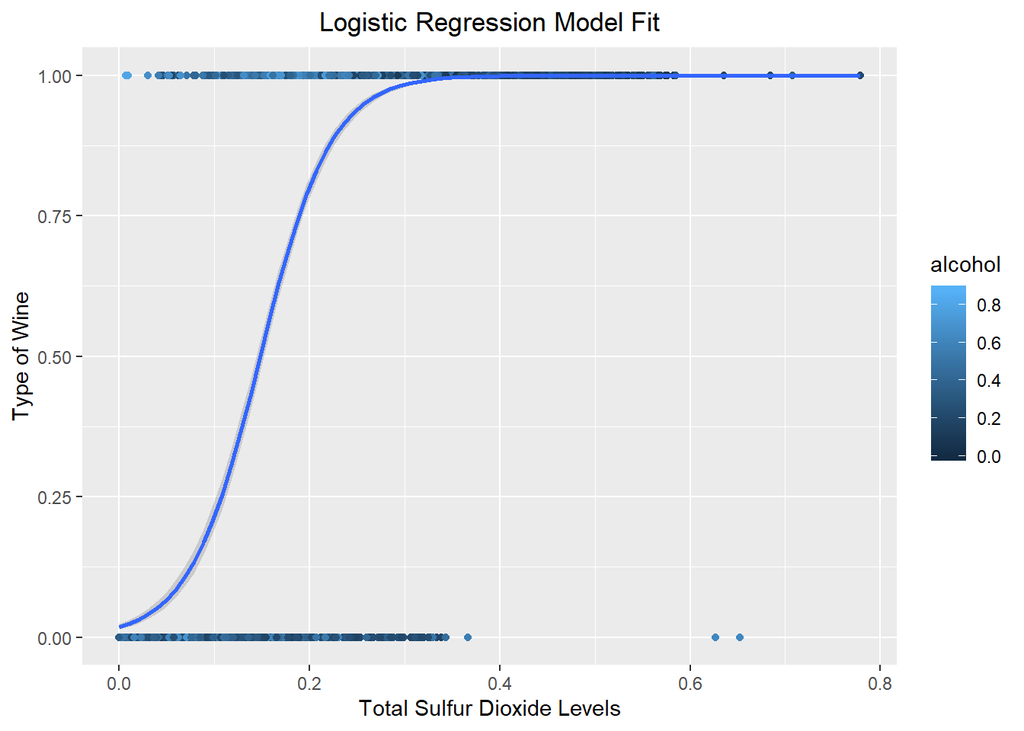

`Type` imposed onto `total.sulfur.dioxide` results in a 93% accuracy rating. Inferring that just knowing your wines level of `total.sulfur.dioxide`, you can predict your wine’s type approximately 93 out of 100 times.

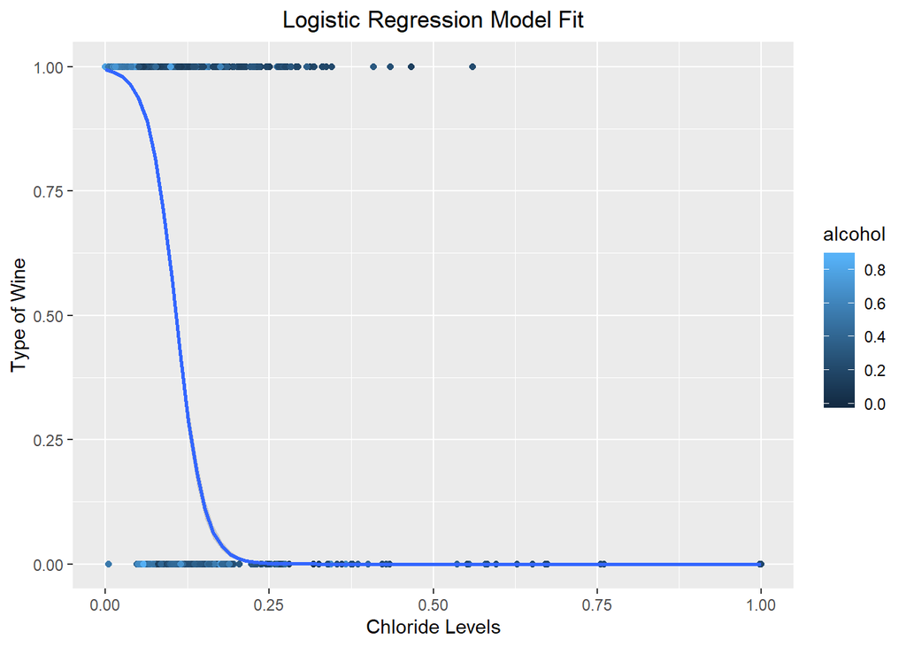

`Type` imposed onto `chlorides` results in a 88% accuracy rating. Inferring that just knowing your wines level of `chlorides`, you can predict your wine’s type approximately 88 out of 100 times.

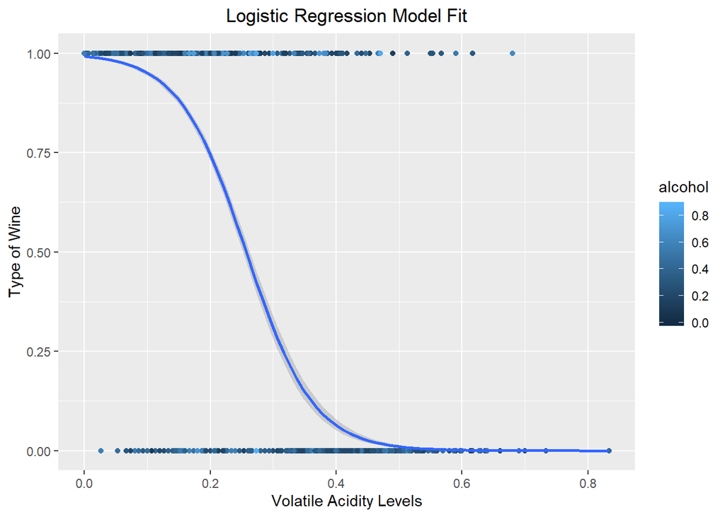